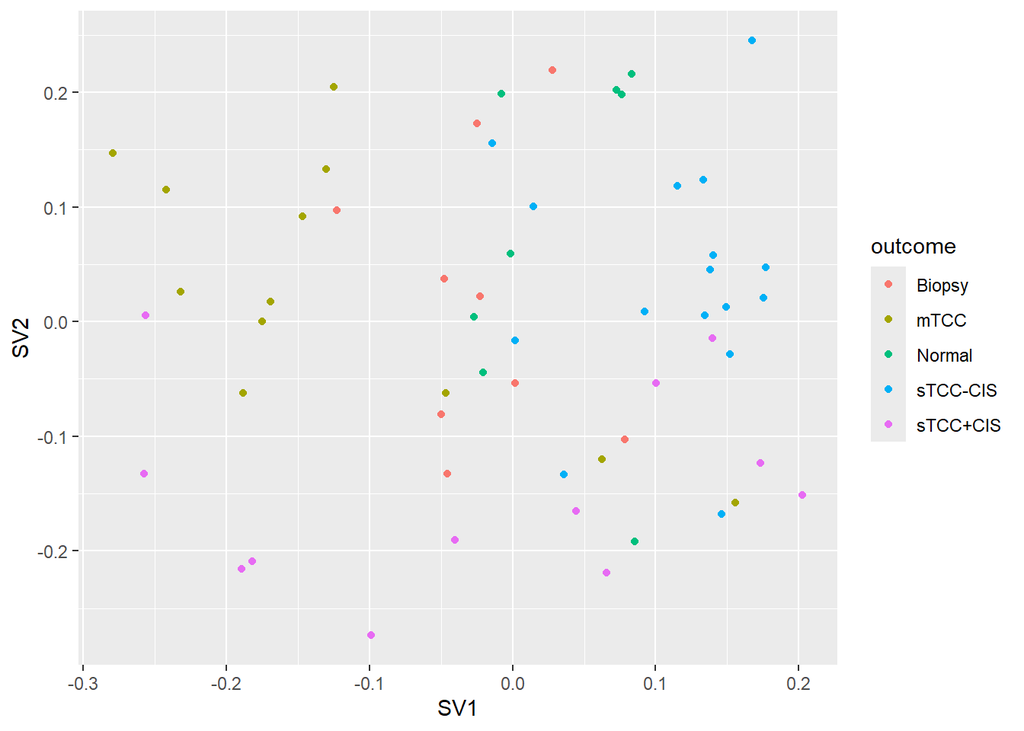

```r
ggplot(sva_batch) + geom_point(aes(x=SV1,y=SV2, col=outcome))
```

We further make the violin plots of values of SVs, stratified by the five batches. If the values of SVs are separately (differentially distributed) among batches, that may be an evidence that SVA are capturing the known technical variables.

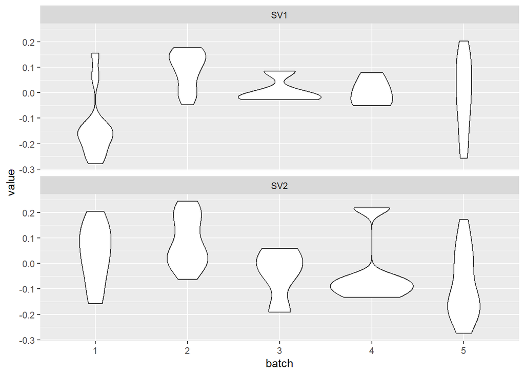

```r
sva_batch <- tibble(SV1=sva_output$sv[,1],
                  SV2=sva_output$sv[,2],
                  batch=as.factor(pheno$batch))
sva_batch_gather <- gather(sva_batch,"sv","value",-batch)

ggplot(sva_batch_gather) + geom_violin(aes(x=batch,y=value)) + facet_wrap(~ sv, ncol = 1)
```

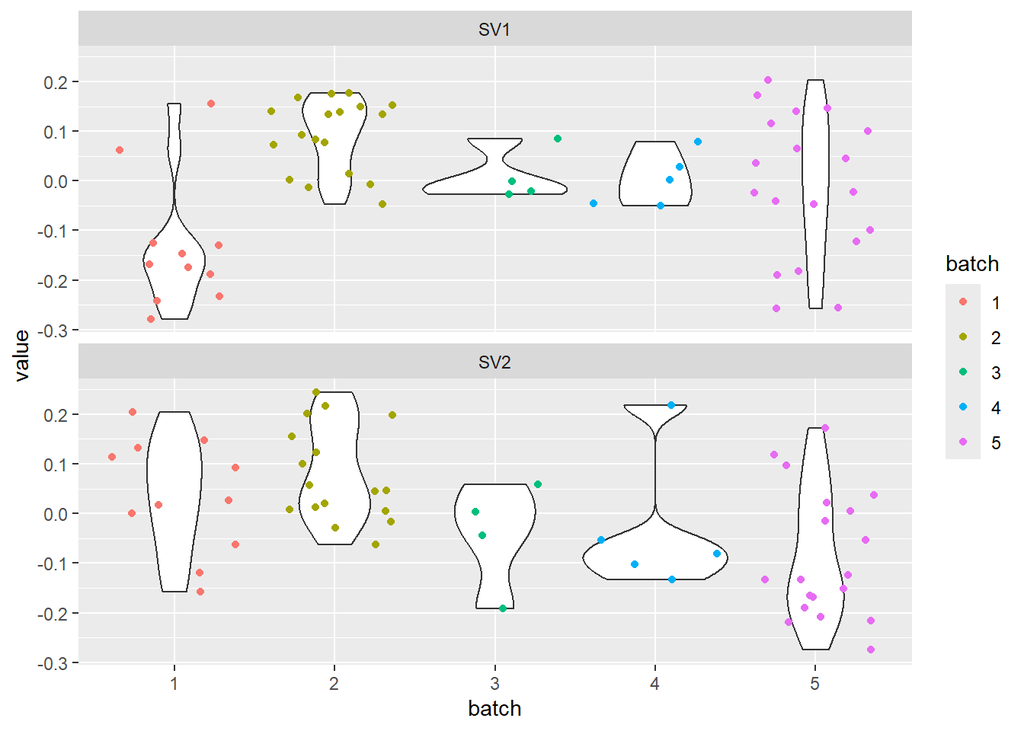

```r
ggplot(sva_batch_gather) + geom_violin(aes(x=batch,y=value)) + facet_wrap(~ sv, ncol = 1) + geom_jitter(aes(x=batch,y=value,col=batch))
```

It seems that 2 surrogate variables (SVs) contain substantial information about a known technical variable. Therefore, we proceed to fit the model.

Note that the following code to visualize estimates are rather complex and long. We are using `filter` to choose rows (cancer factors) and `select` to choose estimates (coefficients).

## Fitting a LM with surrogate variables

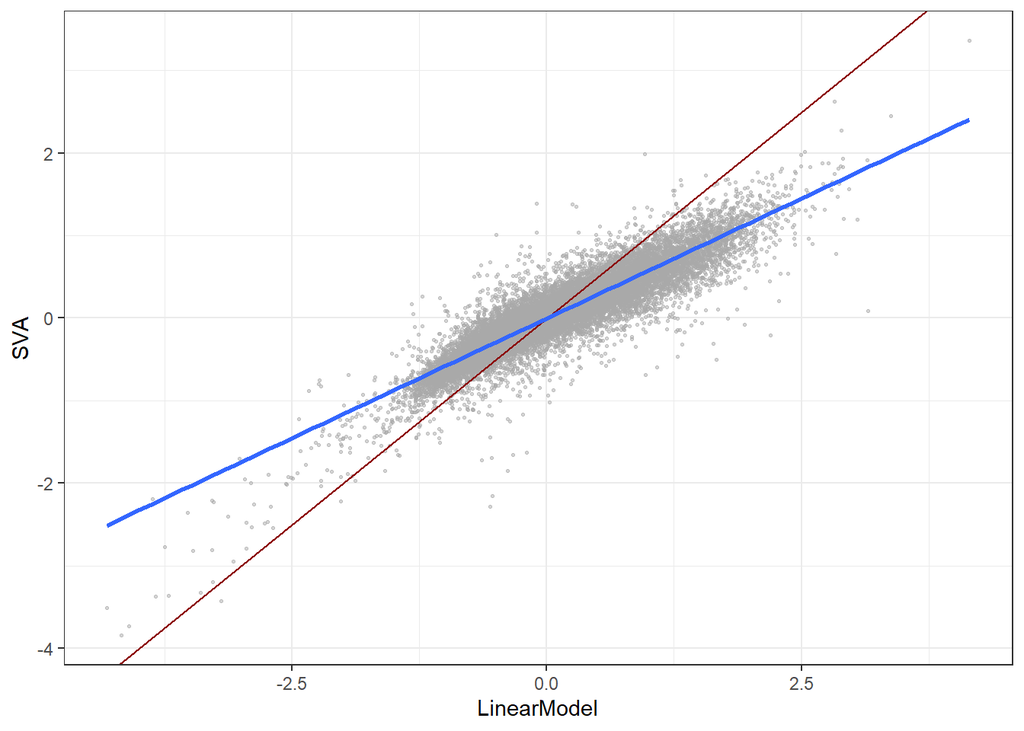

```r
# Add the surrogate variables to the model matrix
modsva = lm(t(edata) ~ as.factor(pheno$cancer) + sva_output$sv)
modsva_tidy <- tidy(modsva)

est_compare <- tibble(
  LinearModel = mod_tidy %>% filter(term == "as.factor(pheno$cancer)Cancer") %>% select("estimate") %>% unlist,

  ComBat = modcombat_tidy %>% filter(term == "as.factor(pheno$cancer)Cancer") %>% select("estimate") %>% unlist,

  SVA = modsva_tidy %>% filter(term == "as.factor(pheno$cancer)Cancer") %>% select("estimate") %>% unlist)

ggplot(est_compare, aes(x=LinearModel, y=SVA)) +
     geom_point(col="darkgrey", alpha=.5, size=.5) + geom_abline(intercept=0, slope=1, col="darkred") + geom_smooth(method = "lm", se = TRUE)  + theme_bw()
```

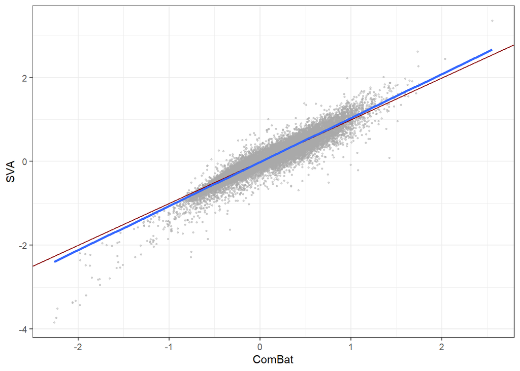

```r
ggplot(est_compare, aes(x=ComBat, y=SVA)) +
     geom_point(col="darkgrey", alpha=.5, size=.5) + geom_abline(intercept=0, slope=1, col="darkred") + geom_smooth(method = "lm", se = TRUE)  + theme_bw()
```

At last, let’s look at the p-values from SVA.

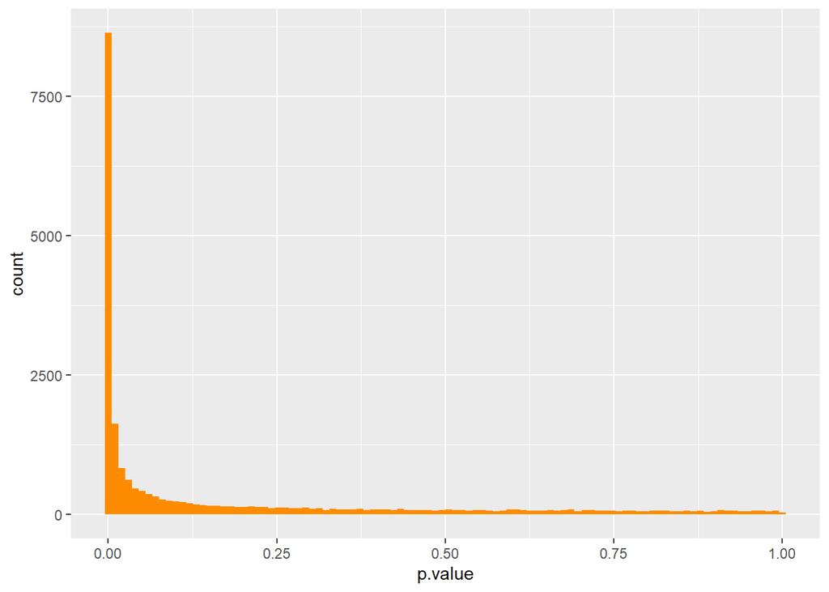

```r
ggplot(modsva_tidy %>% filter(term == "as.factor(pheno$cancer)Cancer")) + geom_histogram(aes(x=p.value), bins = 100, fill="darkorange")
```

It seems that even though the estimates are shrunken towards to zero and the surrogate variables have approximated the technical variables well, the p-values as a whole may not changed so much.

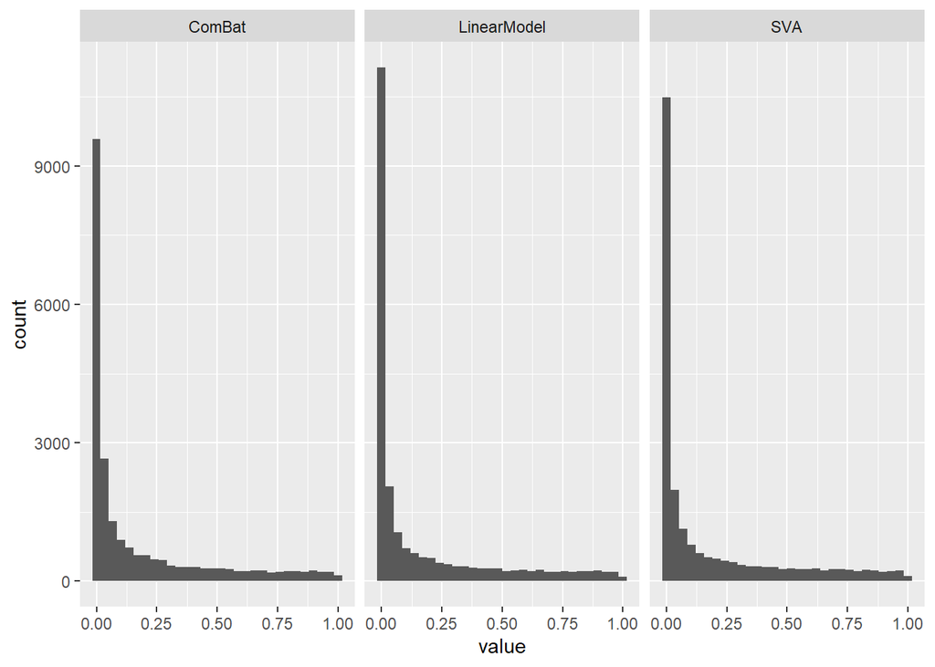

```r
pvalues <- tibble(
  LinearModel = mod_tidy %>% filter(term == "as.factor(pheno$cancer)Cancer") %>% select("p.value") %>% unlist,
  ComBat = modcombat_tidy %>% filter(term == "as.factor(pheno$cancer)Cancer") %>% select("p.value") %>% unlist,
  SVA = modsva_tidy %>% filter(term == "as.factor(pheno$cancer)Cancer") %>% select("p.value") %>% unlist)

pvalues_gather <- gather(pvalues)
ggplot(pvalues_gather, aes(x=value)) + geom_histogram() + facet_wrap(~key)
```

```r
# pi0 from the original data ~ 0.26
# pi0 from a combat-cleaned data ~ 0.28
# pi0 from SVA ~ 0.27
```

> *Homework Problem 5:* Apply ComBat and SVA to the Bottomly et al. data. Make a scatter plots of coefficients and a histogram of p-values, comparing results based on ComBat and SVA. Assume that the biological variables in Bottomly et al data is the genetic strains. Make sure that you are pulling out the correct coefficients/pvalues, not any or all of them.

```r
mod = model.matrix(~ as.factor(pdata$strain), data=pdata)

set.seed(1)
rnorm(1)
```

```
## [1] -0.6264538
```

```r
num.sv(expdata,mod,method="be")
```

```
## [1] 2
```

```r
num.sv(expdata,mod,method="leek")
```

```
## [1] 2
```

```r
mod_bott = model.matrix(~ as.factor(pdata$strain), data=pdata)
mod0_bott = model.matrix(~1, data=pdata)
sva_output_bott = sva(expdata, mod_bott, mod0_bott, n.sv=num.sv(expdata,mod_bott,method="leek"))
```

```
## Number of significant surrogate variables is:  2
## Iteration (out of 5 ):1  2  3  4  5
```

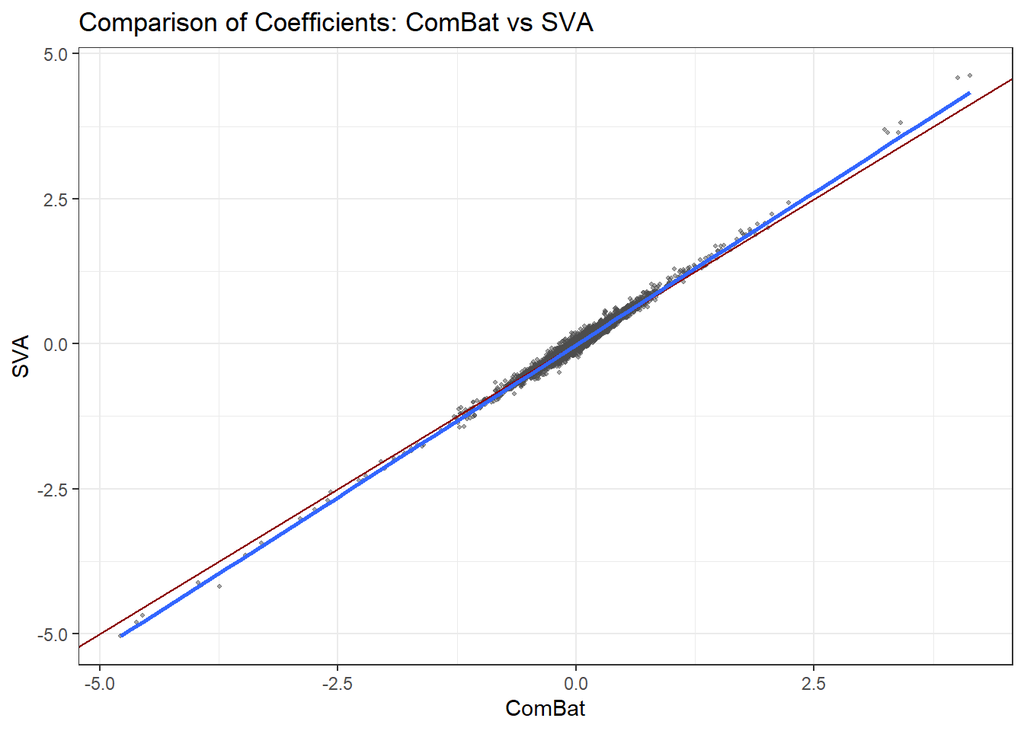

```r
mod_sva_bott = lm(t(expdata) ~ as.factor(pdata$strain) + sva_output_bott$sv)
mod_sva_tidy_bott = tidy(mod_sva_bott)

# Visualisation
est_compare <- tibble(
  ComBat = modbattcombat_tidy %>%
    filter(term == "as.factor(pdata$strain)DBA/2J") %>% pull(estimate),
  SVA = mod_sva_tidy_bott %>%
    filter(term == "as.factor(pdata$strain)DBA/2J") %>% pull(estimate)
)

ggplot(est_compare, aes(x=ComBat, y=SVA)) +
  geom_point(color="grey30", alpha=0.5, size=0.7) +
  geom_abline(slope=1, intercept=0, color="darkred") +
  geom_smooth(method="lm", se=TRUE) +
  theme_bw() +
  labs(title="Comparison of Coefficients: ComBat vs SVA")
```

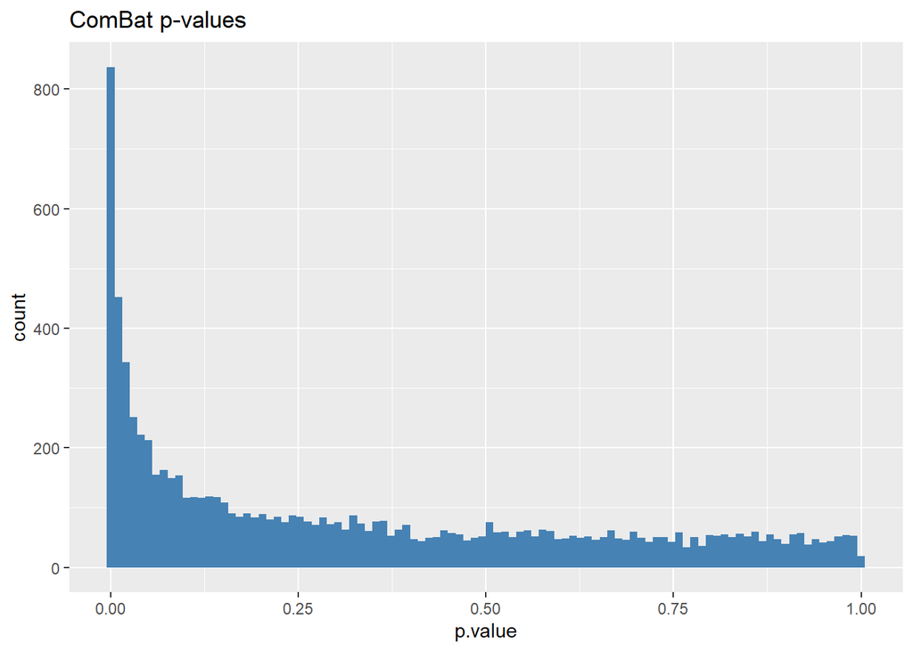

```r
# Histogram for ComBat p-values
ggplot(modbattcombat_tidy %>% filter(term == "as.factor(pdata$strain)DBA/2J")) +
  geom_histogram(aes(x=p.value), bins=100, fill="steelblue") +
  ggtitle("ComBat p-values")
```

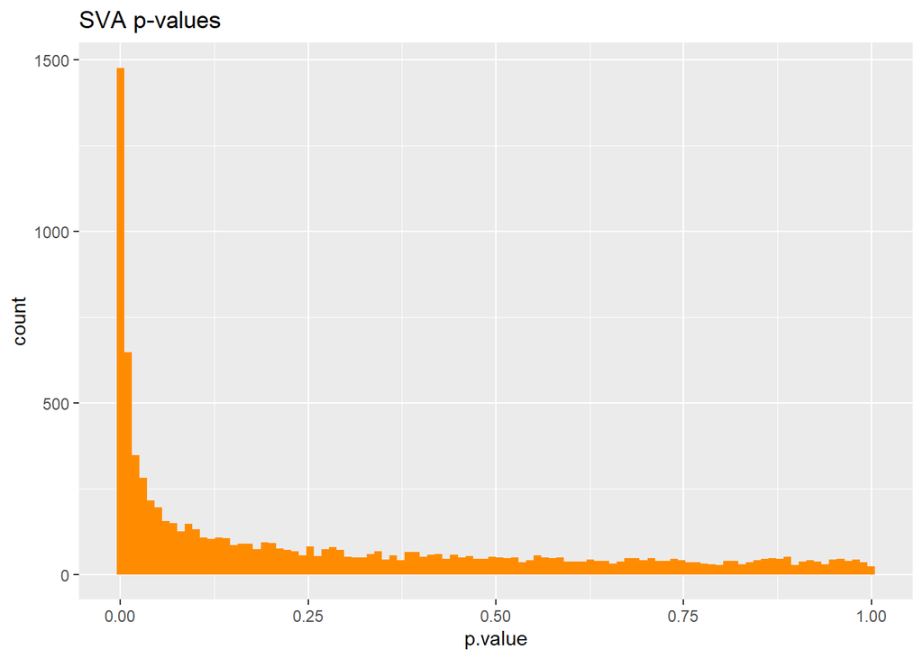

```r
# Histogram for SVA p-values
ggplot(mod_sva_tidy_bott %>% filter(term == "as.factor(pdata$strain)DBA/2J")) +
  geom_histogram(aes(x=p.value), bins=100, fill="darkorange") +
  ggtitle("SVA p-values")
```